# Spatial Data Analysis

Sumendar Karupakala

2017-12-04

# 1 Spatial Data Analysis

## 1.1 Section 1 to 4: Import Data from Various formats

Learning the basics of importing & exploring data in various formats in R such as **tables, Vectors & Rasters** data, then we will see how to work with this data

- Setting with projection
- dealing with time variable

### 1.1.1 Section 1: **Importing Data from Table Format**

- **Importing Data from Table (read.table)**
- **Downloading Open Data from FTP Sites**
- **Fixed-Width-Format**
- **Importing with read.lines(The last resort)**
- **Cleaning Your Data**

#### 1.1.1.1 Importing Data from Table (read.table)

- Opening data
- Importing csv files
- Checking the data structure for consistency

```r
# dataset from USGS=United states geological survey
#Set the URL with the CSV Files
URL <- "http://earthquake.usgs.gov/earthquakes/feed/v1.0/summary/all_day.csv"
#Load the CSV File
Data <- read.table(file=URL,
                   sep=",",
                   header=TRUE,
                   na.string="")
```

```r
#Help function
help(read.table)
```

```r
#Examining the data
str(Data)
```

```
## 'data.frame':    236 obs. of  22 variables:
##  $ time           : Factor w/ 236 levels "2017-12-09T01:38:56.510Z",..: 236 235 234 233 232 231 230 229 228 227 ...
##  $ latitude       : num  38.8 46.5 35.9 33.5 39.6 ...
##  $ longitude      : num  -123 -122 -120 -117 -120 ...
##  $ depth          : num  1.76 7.81 6.36 6.32 7.1 2.44 4.71 0.2 36.1 7.67 ...
##  $ mag            : num  0.94 1.19 0.92 0.56 1 1.38 0.35 1.5 1.6 0.5 ...
##  $ magType        : Factor w/ 6 levels "mb","mb_lg","md",..: 3 4 3 4 4 3 4 4 4 4 ...
##  $ nst            : int  11 21 11 22 6 17 17 NA NA 19 ...
##  $ gap            : num  130 182 126 46 150 ...
##  $ dmin           : num  0.00272 0.09782 0.01499 0.01398 0.018 ...
##  $ rms            : num  0.05 0.08 0.03 0.14 NA 0.04 0.19 0.53 0.56 0.26 ...
##  $ net            : Factor w/ 8 levels "ak","ci","hv",..: 4 8 4 2 5 4 2 1 1 2 ...
##  $ id             : Factor w/ 236 levels "ak17545480","ak17546841",..: 174 236 173 113 218 172 112 50 49 111 ...
##  $ updated        : Factor w/ 236 levels "2017-12-09T01:46:58.146Z",..: 236 234 233 230 227 231 225 228 221 217 ...
##  $ place          : Factor w/ 164 levels "109km WSW of Gustavus, Alaska",..: 144 103 100 15 88 140 160 53 51 2 ...
##  $ type           : Factor w/ 1 level "earthquake": 1 1 1 1 1 1 1 1 1 1 ...
##  $ horizontalError: num  0.41 0.66 0.61 0.22 NA 0.35 0.59 NA NA 0.51 ...
##  $ depthError     : num  0.77 0.35 1.2 0.59 NA 0.47 0.46 0.5 0.6 1.42 ...
##  $ magError       : num  0.08 0.198 0.44 0.21 NA 0.12 0.115 NA NA 0.141 ...
##  $ magNst         : int  2 17 3 18 NA 13 10 NA NA 12 ...
##  $ status         : Factor w/ 2 levels "automatic","reviewed": 1 2 1 1 1 1 1 1 1 1 ...
##  $ locationSource : Factor w/ 8 levels "ak","ci","hv",..: 4 8 4 2 5 4 2 1 1 2 ...
##  $ magSource      : Factor w/ 8 levels "ak","ci","hv",..: 4 8 4 2 5 4 2 1 1 2 ...
```

```r
head(Data, 3)
```

```
##                       time latitude longitude depth  mag magType nst gap
## 1 2017-12-10T01:14:39.820Z 38.82567 -122.8120  1.76 0.94      md  11 130
## 2 2017-12-10T01:04:23.650Z 46.52633 -122.3037  7.81 1.19      ml  21 182
## 3 2017-12-10T00:58:28.170Z 35.92550 -120.4655  6.36 0.92      md  11 126
##       dmin  rms net         id                  updated
## 1 0.002722 0.05  nc nc72937756 2017-12-10T01:25:02.883Z
## 2 0.097820 0.08  uw uw61334657 2017-12-10T01:13:34.280Z
## 3 0.014990 0.03  nc nc72937746 2017-12-10T01:13:02.860Z
##                           place       type horizontalError depthError
## 1     7km NW of The Geysers, CA earthquake            0.41       0.77
## 2 4km SSW of Morton, Washington earthquake            0.66       0.35
## 3       4km NW of Parkfield, CA earthquake            0.61       1.20
##   magError magNst    status locationSource magSource
## 1    0.080      2 automatic             nc        nc
## 2    0.198     17  reviewed             uw        uw
## 3    0.440      3 automatic             nc        nc
```

#### 1.1.1.2 Downloading Open Data from FTP Sites

- Downloading Open data from FTP sites
- Creating a new folder to save them
- De-compress them

```r
#dataset from NOAA-national oceanic and atmospheric adminstration
#Load required packages
library(RCurl)
library(XML)
```

```r
#Create a list with all the files on the FTP site
list <- getURL("ftp://ftp.ncdc.noaa.gov/pub/data/gsod/2016/",
               dirlistonly = TRUE)

#Clean the list
FileList <- strsplit(list, split="\r\n")
```

```r
#Create a new directory where to download these files
DIR <- paste(getwd(),"/NOAAFiles",sep="")
dir.create(DIR)
for(FileName in unlist(FileList)){
  URL <- paste0("ftp://ftp.ncdc.noaa.gov/pub/data/gsod/2016/",FileName)
  download.file(URL, destfile=paste0(DIR,"/",FileName), method="auto",
                mode="wb")
}
```

```r
#A more elegant way
DownloadFile <- function(x){
  URL <- paste0("ftp://ftp.ncdc.noaa.gov/pub/data/gsod/2016/",x)
  download.file(URL, destfile=paste0(DIR,"/",x), method="auto", mode="wb")
}
```

```r
lapply(unlist(FileList)[1:5], DownloadFile)
```

```r
#Dowload a compressed file
URL <- "ftp://ftp.ncdc.noaa.gov/pub/data/gsod/2015/gsod_2015.tar"
download.file(URL, destfile=paste0(DIR,"/gsod_2015.tar"),
              method="auto",mode="wb")

untar(paste0(getwd(),"/NOAAFiles/","gsod_2015.tar"),
      exdir=paste0(getwd(),"/NOAAFiles"))
```

#### 1.1.1.3 Fixed-Width-Format

- Creating a list of files in a folder
- Opening data compressed in gzip
- Opening data in fixed width format

```r
mywd <- getwd()
setwd(paste0(mywd,'/NOAAFiles'))
# getwd()
#Create a list with all the files in the directory
FileList <- list.files(path=".", pattern=".gz", full.names=FALSE)
```

```r
help(list.files)
```

```r
#Open the first file in the list
data <- read.fwf(gzfile(FileList[1],open="rt"),
                 header=F,
                 skip=1,
                 widths=c(6,1,5,2,8,4,4,108))
```

#### 1.1.1.4 Importing with read.lines(The last resort)

- Some data cannot be open with neither read.table nor read.fwf
- In these desperate cases in readLines can help

```r
URL <- "ftp://ftp.ncdc.noaa.gov/pub/data/noaa/2015/010231-99999-2015.gz"

FileName <- "010231-99999-2015.gz"

download.file(URL, destfile=paste0(getwd(),"/",FileName), method="auto", mode="wb")

data.strings <- readLines(gzfile(FileName, open="rt"))

str(data.strings)
data.strings[[1]]
```

```r
#Download the data from the FTP site
URL <- "ftp://ftp.ncdc.noaa.gov/pub/data/noaa/2015/010231-99999-2015.gz"
FileName <- "010231-99999-2015.gz"
download.file(URL, destfile=paste0(getwd(),"/",FileName), method="auto", mode="wb")

data.strings <- readLines(gzfile(FileName, open="rt"))
```

#### 1.1.1.5 Cleaning Your Data

- Reading a data file is not sufficient
- We need to be able to extract only the information we need

```r
#Download the data from the FTP site
URL <- "ftp://ftp.ncdc.noaa.gov/pub/data/noaa/2015/010231-99999-2015.gz"
FileName <- "010231-99999-2015.gz"
download.file(URL, destfile=paste0(getwd(),"/",FileName), method="auto",
              mode="wb")

data.strings <- readLines(gzfile(FileName, open="rt"))
#The format for these data is available at:
#ftp://ftp.ncdc.noaa.gov/pub/data/noaa/ish-format-document.pdf

#Create function to extract temperature data
Ext.Temp <- function(x){
  substr(x, 88, 92)
}
```

```r
#Create a vector with temperature data
TEMP <- lapply(data.strings, Ext.Temp)
length(TEMP)
```

```
## [1] 17291
```

```r
head(unlist(TEMP),100)
```

```
##   [1] "+0080" "+0080" "+0080" "+0080" "+0080" "+0080" "+0080" "+0080"
##   [9] "+0080" "+0080" "+0080" "+0080" "+0080" "+0080" "+0090" "+0070"
##  [17] "+0080" "+0080" "+0080" "+0080" "+0080" "+0080" "+0080" "+0090"
##  [25] "+0080" "+0080" "+0080" "+0050" "+0070" "+0070" "+0080" "+0070"
##  [33] "+0050" "+0070" "+0070" "+0060" "+0070" "+0070" "+0070" "+0070"
##  [41] "+0070" "+0060" "+0060" "+0060" "+0060" "+0050" "+0050" "+0050"
##  [49] "+0050" "+0040" "+0050" "+0060" "+0060" "+0060" "+0060" "+0060"
##  [57] "+0040" "+0050" "+0060" "+0060" "+0060" "+0060" "+0050" "+0050"
##  [65] "+0050" "+0060" "+0050" "+0050" "+0050" "+0050" "+0050" "+0050"
##  [73] "+0050" "+0050" "+0050" "+0050" "+0050" "+0050" "+0050" "+0050"
##  [81] "+0060" "+0050" "+0040" "+0020" "+0050" "+0040" "+0050" "+0060"
##  [89] "+0050" "+0040" "+0030" "+0040" "+0050" "+0050" "+0050" "+0050"
##  [97] "+0050" "+0040" "+0020" "+0040"
```

```r
temp.data <- as.numeric(paste(unlist(TEMP)))
```

```r
#Functions
Ext.Latitude <- function(x){
  substr(x, start=29, stop=34)
}

Ext.Longitude <- function(x){
  substr(x, start=35, stop=41)
}

Ext.Temp <- function(x){
  substr(x, start=88, stop=92)
}
```

```r
LAT <- lapply(data.strings, Ext.Latitude)
LON <- lapply(data.strings, Ext.Longitude)
TEMP <- lapply(data.strings, Ext.Temp)
```

```r
#Create a data.frame we can use for data analysis
DATA <- data.frame(Latitude=as.numeric(unlist(LAT))/1000,
                   Longitude=as.numeric(unlist(LON))/1000,
                   Temperature=as.numeric(unlist(TEMP))/10)

DATA[DATA$Temperature==999.9,"Temperature"] <- NA

str(DATA)
```

```
## 'data.frame':    17291 obs. of  3 variables:
##  $ Latitude   : num  64.3 64.3 64.3 64.3 64.3 ...
##  $ Longitude  : num  7.8 7.8 7.8 7.8 7.8 7.8 7.8 7.8 7.8 7.8 ...
##  $ Temperature: num  8 8 8 8 8 8 8 8 8 8 ...
```

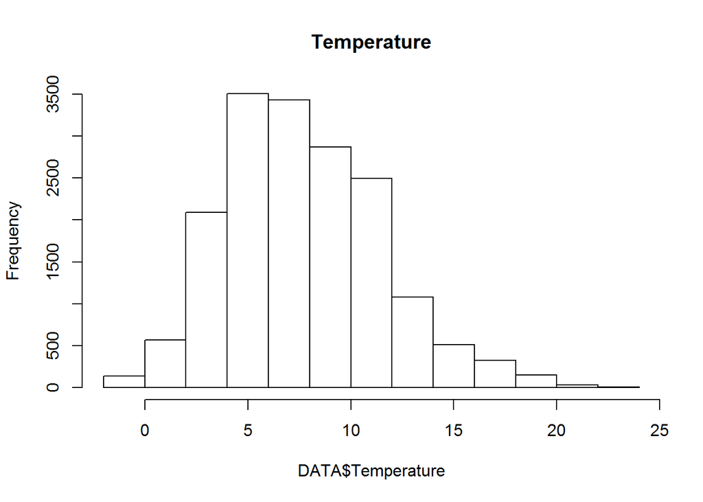

```r
hist(DATA$Temperature, main="Temperature")
```

### 1.1.2 Section 2: **Handling the Temportal Component**

- **Loading the Required Packages**
- **Importing Vector Data(ESRI shp and GeoJSON)**
- **Transforming data.frame to SpatialPoinDataFrame**
- **Understanding Projections**
- **Basic time/date formats (Temporal Component)- Working with advanced temporal formats(POSIXct/POSIXlt)]**

#### 1.1.2.1 Loading the Required Packages

- Packages for spatial analysis in R
- Installing these packages
- Additional sources of information

```r
library("sp", lib.loc="~/R/win-library/3.4") #Classes and Methods for Spatial Data
library("rgdal", lib.loc="~/R/win-library/3.4") #Bindings for the 'Geospatial' Data Abstraction Library
library("raster", lib.loc="~/R/win-library/3.4") #Reading, writing, manipulating, analyzing and modeling of gridded spatial data, allows to import the raster data without loading into memory usefull for large data
library("rgeos", lib.loc="~/R/win-library/3.4") #basics spatial data manipulation functions allow us to use R as GEOS application
library(RCurl,lib.loc="~/R/win-library/3.4")
```

#### 1.1.2.2 Importing Vector Data(ESRI shp and GeoJSON)

- import shapefiles
- Ways to load vector data in rgdal and raster
- Importing GeoJSON data

```r
#For ESRI Shapefile we will use country boundaries from NaturalEarth
#http://www.naturalearthdata.com
URL <- "http://www.naturalearthdata.com/http//www.naturalearthdata.com/download/110m/cultural/ne_110m_admin_0_countries.zip"

FileName <- "ne_110m_admin_0_countries.zip"

dir.create(paste0(getwd(),"/Shapefile"))

download.file(URL,
              destfile=paste0(getwd(),"/Shapefile/",FileName))
unzip(paste0(getwd(),"/Shapefile/",FileName),
      exdir=paste0(getwd(),"/Shapefile",sep=""))
```

```r
#There are two ways to load an ESRI Shapefile
#The first is with the function readOGR in rgdal
NatEarthOGR <- readOGR(dsn="Shapefile/ne_110m_admin_0_countries.shp",
                       layer="ne_110m_admin_0_countries")
class(NatEarthOGR)
```

```
## [1] "SpatialPolygonsDataFrame"
## attr(,"package")
## [1] "sp"
```

```r
names(NatEarthOGR)
```

```
##  [1] "scalerank"  "featurecla" "LABELRANK"  "SOVEREIGNT" "SOV_A3"
##  [6] "ADM0_DIF"   "LEVEL"      "TYPE"       "ADMIN"      "ADM0_A3"
## [11] "GEOU_DIF"   "GEOUNIT"    "GU_A3"      "SU_DIF"     "SUBUNIT"
## [16] "SU_A3"      "BRK_DIFF"   "NAME"       "NAME_LONG"  "BRK_A3"
## [21] "BRK_NAME"   "BRK_GROUP"  "ABBREV"     "POSTAL"     "FORMAL_EN"
## [26] "FORMAL_FR"  "NAME_CIAWF" "NOTE_ADM0"  "NOTE_BRK"   "NAME_SORT"
## [31] "NAME_ALT"   "MAPCOLOR7"  "MAPCOLOR8"  "MAPCOLOR9"  "MAPCOLOR13"
## [36] "POP_EST"    "POP_RANK"   "GDP_MD_EST" "POP_YEAR"   "LASTCENSUS"
## [41] "GDP_YEAR"   "ECONOMY"    "INCOME_GRP" "WIKIPEDIA"  "FIPS_10_"
## [46] "ISO_A2"     "ISO_A3"     "ISO_A3_EH"  "ISO_N3"     "UN_A3"
## [51] "WB_A2"      "WB_A3"      "WOE_ID"     "WOE_ID_EH"  "WOE_NOTE"
## [56] "ADM0_A3_IS" "ADM0_A3_US" "ADM0_A3_UN" "ADM0_A3_WB" "CONTINENT"
## [61] "REGION_UN"  "SUBREGION"  "REGION_WB"  "NAME_LEN"   "LONG_LEN"
## [66] "ABBREV_LEN" "TINY"       "HOMEPART"   "MIN_ZOOM"   "MIN_LABEL"
## [71] "MAX_LABEL"
```

```r
nrow(NatEarthOGR)
```

```
## [1] 177
```

```r
#The second is the simplest method, and can be done with the function
#shapefile in the package raster.
NatEarth <- shapefile("Shapefile/ne_110m_admin_0_countries.shp")

class(NatEarth)
```

```
## [1] "SpatialPolygonsDataFrame"
## attr(,"package")
## [1] "sp"
```

```r
names(NatEarth)
```

```
##  [1] "scalerank"  "featurecla" "LABELRANK"  "SOVEREIGNT" "SOV_A3"
##  [6] "ADM0_DIF"   "LEVEL"      "TYPE"       "ADMIN"      "ADM0_A3"
## [11] "GEOU_DIF"   "GEOUNIT"    "GU_A3"      "SU_DIF"     "SUBUNIT"
## [16] "SU_A3"      "BRK_DIFF"   "NAME"       "NAME_LONG"  "BRK_A3"
## [21] "BRK_NAME"   "BRK_GROUP"  "ABBREV"     "POSTAL"     "FORMAL_EN"
## [26] "FORMAL_FR"  "NAME_CIAWF" "NOTE_ADM0"  "NOTE_BRK"   "NAME_SORT"
## [31] "NAME_ALT"   "MAPCOLOR7"  "MAPCOLOR8"  "MAPCOLOR9"  "MAPCOLOR13"
## [36] "POP_EST"    "POP_RANK"   "GDP_MD_EST" "POP_YEAR"   "LASTCENSUS"
## [41] "GDP_YEAR"   "ECONOMY"    "INCOME_GRP" "WIKIPEDIA"  "FIPS_10_"
## [46] "ISO_A2"     "ISO_A3"     "ISO_A3_EH"  "ISO_N3"     "UN_A3"
## [51] "WB_A2"      "WB_A3"      "WOE_ID"     "WOE_ID_EH"  "WOE_NOTE"
## [56] "ADM0_A3_IS" "ADM0_A3_US" "ADM0_A3_UN" "ADM0_A3_WB" "CONTINENT"
## [61] "REGION_UN"  "SUBREGION"  "REGION_WB"  "NAME_LEN"   "LONG_LEN"
## [66] "ABBREV_LEN" "TINY"       "HOMEPART"   "MIN_ZOOM"   "MIN_LABEL"
## [71] "MAX_LABEL"
```

```r
nrow(NatEarth)
```

```
## [1] 177
```

```r
#Import GeoJSON
#For this example we will use the open data provided by the City of Edinburgh
#available at the following address:
#http://edinburghopendata.info/

#In particular, we will import a dataset of litter reports, which is distributed in GeoJSON
URL <- "http://data.edinburghopendata.info/dataset/53e1cad1-0884-444c-94f1-615bca60a033/resource/3fe94d38-5761-426d-804f-042466b20111/download/litter201501.geojson"
GeoJSON_Edimburgh <- readOGR(getURL(URL), "OGRGeoJSON")
```

```
## Source: "{"type":"FeatureCollection","features":[{"type":"Feature","geometry":{"type":"Point","coordinates":[-3.4034481467375,55.937370760083]},"properties":{"date created":"02\/01\/2015 01.21 PM"}},{"type":"Feature","geometry":{"type":"Point","coordinates":[-3.2119848129202,55.920817435948]},"pr…
## ", layer: "OGRGeoJSON"
```

```r
class(GeoJSON_Edimburgh)
```

```
## [1] "SpatialPointsDataFrame"
## attr(,"package")
## [1] "sp"
```

```r
names(GeoJSON_Edimburgh)
```

```
## [1] "date.created"
```

```r
nrow(GeoJSON_Edimburgh)
```

```
## [1] 202
```

```r
dim(GeoJSON_Edimburgh)
```

```
## [1] 202   1
```

#### 1.1.2.3 Transforming data.frame to SpatialPoinDataFrame

- Transforming a normal CSV into a spatial object
- Understanding the changes in format

```r
#Set the URL with the CSV Files
URL <- "http://earthquake.usgs.gov/earthquakes/feed/v1.0/summary/all_day.csv"


#Loading CSV Files
Data <- read.table(file=URL,
                   sep=",",
                   header=TRUE,
                   na.string="")

#At this point we have a data.frame, we can take a look at its structure
#with the function str(...)
str(Data)
```

```
## 'data.frame':    236 obs. of  22 variables:
##  $ time           : Factor w/ 236 levels "2017-12-09T01:38:56.510Z",..: 236 235 234 233 232 231 230 229 228 227 ...
##  $ latitude       : num  38.8 46.5 35.9 33.5 39.6 ...
##  $ longitude      : num  -123 -122 -120 -117 -120 ...
##  $ depth          : num  1.76 7.81 6.36 6.32 7.1 2.44 4.71 0.2 36.1 7.67 ...
##  $ mag            : num  0.94 1.19 0.92 0.56 1 1.38 0.35 1.5 1.6 0.5 ...
##  $ magType        : Factor w/ 6 levels "mb","mb_lg","md",..: 3 4 3 4 4 3 4 4 4 4 ...
##  $ nst            : int  11 21 11 22 6 17 17 NA NA 19 ...
##  $ gap            : num  130 182 126 46 150 ...
##  $ dmin           : num  0.00272 0.09782 0.01499 0.01398 0.018 ...
##  $ rms            : num  0.05 0.08 0.03 0.14 NA 0.04 0.19 0.53 0.56 0.26 ...
##  $ net            : Factor w/ 8 levels "ak","ci","hv",..: 4 8 4 2 5 4 2 1 1 2 ...
##  $ id             : Factor w/ 236 levels "ak17545480","ak17546841",..: 174 236 173 113 218 172 112 50 49 111 ...
##  $ updated        : Factor w/ 236 levels "2017-12-09T01:46:58.146Z",..: 236 234 233 230 227 231 225 228 221 217 ...
##  $ place          : Factor w/ 164 levels "109km WSW of Gustavus, Alaska",..: 144 103 100 15 88 140 160 53 51 2 ...
##  $ type           : Factor w/ 1 level "earthquake": 1 1 1 1 1 1 1 1 1 1 ...
##  $ horizontalError: num  0.41 0.66 0.61 0.22 NA 0.35 0.59 NA NA 0.51 ...
##  $ depthError     : num  0.77 0.35 1.2 0.59 NA 0.47 0.46 0.5 0.6 1.42 ...
##  $ magError       : num  0.08 0.198 0.44 0.21 NA 0.12 0.115 NA NA 0.141 ...
##  $ magNst         : int  2 17 3 18 NA 13 10 NA NA 12 ...
##  $ status         : Factor w/ 2 levels "automatic","reviewed": 1 2 1 1 1 1 1 1 1 1 ...
##  $ locationSource : Factor w/ 8 levels "ak","ci","hv",..: 4 8 4 2 5 4 2 1 1 2 ...
##  $ magSource      : Factor w/ 8 levels "ak","ci","hv",..: 4 8 4 2 5 4 2 1 1 2 ...
```

```r
#Extract the magnitude of the events is simple:
Data$mag
```

```
##   [1]  0.94  1.19  0.92  0.56  1.00  1.38  0.35  1.50  1.60  0.50  0.71
##  [12]  0.93  2.29  2.46  2.40  2.36  1.31  1.40  0.53  2.07  0.76  1.41
##  [23]  2.30  0.47  2.20  0.82  1.60  2.80  1.18 -0.20  0.60 -0.20  0.74
##  [34]  0.80  1.90  2.50  0.30  0.57  2.36  1.04  0.36  0.49  0.47  1.43
##  [45]  0.49  0.60  0.82  1.31  0.74  2.00  0.76  0.55  1.71  3.48  2.00
##  [56]  0.81  2.80  1.45 -0.30  4.30  0.80  2.67  1.35  5.00 -0.20  0.40
##  [67]  2.10  0.73  1.10  1.28  1.04  2.10  2.69  0.30  0.48  0.70  1.60
##  [78]  1.80 -0.20  0.51  0.19  2.20  2.73  0.40  2.58  2.10  1.20  2.80
##  [89]  0.30  1.39  4.50  0.48  0.89  6.10  1.00  1.20  1.80 -0.10  2.10
## [100]  0.93  2.04  1.11  1.15  0.30  0.00  1.50  1.93  1.20  1.80  1.65
## [111]  3.07  1.70  2.40  0.00 -0.20  0.30  0.10  0.72  0.28  1.20  0.86
## [122]  0.79  0.57  1.90  1.12  0.32 -0.20  1.06  3.80  0.20  0.62  0.69
## [133]  4.60  1.46  0.90  1.10  0.44  0.50  0.30  2.12  1.70  1.40  1.70
## [144]  1.40  0.56  0.53  2.80  1.30 -0.20  2.10  0.80  0.89  0.30 -0.12
## [155]  0.19  1.27  1.02  3.61  0.85  1.00  2.10  1.90  0.10  1.20  1.01
## [166]  1.80  3.00  4.70  2.82  4.00  1.50  0.52  2.22  1.40  0.84  0.80
## [177]  1.65  1.83  0.58  2.50  2.30  1.66  0.40  1.37 -0.20  0.68  2.26
## [188]  0.86  1.70  1.60  0.73  2.03  0.70  1.70  4.30  0.80  1.33 -0.10
## [199]  2.06  0.30  2.28  2.50  1.11  2.80  0.00  0.20  1.80  1.20  1.48
## [210]  1.11  0.18  1.00  0.00  0.81  0.68  1.30  2.27  3.09  0.19  0.98
## [221]  0.48  0.88  3.52  0.48  4.50  1.78  0.57  0.44  1.50  2.02  0.35
## [232]  0.28  1.90  1.93  0.03  2.01
```

```r
#Transformation into a spatial object
coordinates(Data)=~longitude+latitude
```

```r
#If we run the str function now we will notice some differences
str(Data)
```

```
## Formal class 'SpatialPointsDataFrame' [package "sp"] with 5 slots
##   ..@ data       :'data.frame':  236 obs. of  20 variables:
##   .. ..$ time           : Factor w/ 236 levels "2017-12-09T01:38:56.510Z",..: 236 235 234 233 232 231 230 229 228 227 ...
##   .. ..$ depth          : num [1:236] 1.76 7.81 6.36 6.32 7.1 2.44 4.71 0.2 36.1 7.67 ...
##   .. ..$ mag            : num [1:236] 0.94 1.19 0.92 0.56 1 1.38 0.35 1.5 1.6 0.5 ...
##   .. ..$ magType        : Factor w/ 6 levels "mb","mb_lg","md",..: 3 4 3 4 4 3 4 4 4 4 ...
##   .. ..$ nst            : int [1:236] 11 21 11 22 6 17 17 NA NA 19 ...
##   .. ..$ gap            : num [1:236] 130 182 126 46 150 ...
##   .. ..$ dmin           : num [1:236] 0.00272 0.09782 0.01499 0.01398 0.018 ...
##   .. ..$ rms            : num [1:236] 0.05 0.08 0.03 0.14 NA 0.04 0.19 0.53 0.56 0.26 ...
##   .. ..$ net            : Factor w/ 8 levels "ak","ci","hv",..: 4 8 4 2 5 4 2 1 1 2 ...
##   .. ..$ id             : Factor w/ 236 levels "ak17545480","ak17546841",..: 174 236 173 113 218 172 112 50 49 111 ...
##   .. ..$ updated        : Factor w/ 236 levels "2017-12-09T01:46:58.146Z",..: 236 234 233 230 227 231 225 228 221 217 ...
##   .. ..$ place          : Factor w/ 164 levels "109km WSW of Gustavus, Alaska",..: 144 103 100 15 88 140 160 53 51 2 ...
##   .. ..$ type           : Factor w/ 1 level "earthquake": 1 1 1 1 1 1 1 1 1 1 ...
##   .. ..$ horizontalError: num [1:236] 0.41 0.66 0.61 0.22 NA 0.35 0.59 NA NA 0.51 ...
##   .. ..$ depthError     : num [1:236] 0.77 0.35 1.2 0.59 NA 0.47 0.46 0.5 0.6 1.42 ...
##   .. ..$ magError       : num [1:236] 0.08 0.198 0.44 0.21 NA 0.12 0.115 NA NA 0.141 ...
##   .. ..$ magNst         : int [1:236] 2 17 3 18 NA 13 10 NA NA 12 ...
##   .. ..$ status         : Factor w/ 2 levels "automatic","reviewed": 1 2 1 1 1 1 1 1 1 1 ...
##   .. ..$ locationSource : Factor w/ 8 levels "ak","ci","hv",..: 4 8 4 2 5 4 2 1 1 2 ...
##   .. ..$ magSource      : Factor w/ 8 levels "ak","ci","hv",..: 4 8 4 2 5 4 2 1 1 2 ...
##   ..@ coords.nrs : int [1:2] 3 2
##   ..@ coords     : num [1:236, 1:2] -123 -122 -120 -117 -120 ...
##   .. ..- attr(*, "dimnames")=List of 2
##   .. .. ..$ : chr [1:236] "1" "2" "3" "4" ...
##   .. .. ..$ : chr [1:2] "longitude" "latitude"
##   ..@ bbox       : num [1:2, 1:2] -176.1 -24.1 140.2 67.2
##   .. ..- attr(*, "dimnames")=List of 2
##   .. .. ..$ : chr [1:2] "longitude" "latitude"
##   .. .. ..$ : chr [1:2] "min" "max"
##   ..@ proj4string:Formal class 'CRS' [package "sp"] with 1 slot
##   .. .. ..@ projargs: chr NA
```

```r
#However, accessing the magnitude info can be done in the same way.
Data$mag
```

```
##   [1]  0.94  1.19  0.92  0.56  1.00  1.38  0.35  1.50  1.60  0.50  0.71
##  [12]  0.93  2.29  2.46  2.40  2.36  1.31  1.40  0.53  2.07  0.76  1.41
##  [23]  2.30  0.47  2.20  0.82  1.60  2.80  1.18 -0.20  0.60 -0.20  0.74
##  [34]  0.80  1.90  2.50  0.30  0.57  2.36  1.04  0.36  0.49  0.47  1.43
##  [45]  0.49  0.60  0.82  1.31  0.74  2.00  0.76  0.55  1.71  3.48  2.00
##  [56]  0.81  2.80  1.45 -0.30  4.30  0.80  2.67  1.35  5.00 -0.20  0.40
##  [67]  2.10  0.73  1.10  1.28  1.04  2.10  2.69  0.30  0.48  0.70  1.60
##  [78]  1.80 -0.20  0.51  0.19  2.20  2.73  0.40  2.58  2.10  1.20  2.80
##  [89]  0.30  1.39  4.50  0.48  0.89  6.10  1.00  1.20  1.80 -0.10  2.10
## [100]  0.93  2.04  1.11  1.15  0.30  0.00  1.50  1.93  1.20  1.80  1.65
## [111]  3.07  1.70  2.40  0.00 -0.20  0.30  0.10  0.72  0.28  1.20  0.86
## [122]  0.79  0.57  1.90  1.12  0.32 -0.20  1.06  3.80  0.20  0.62  0.69
## [133]  4.60  1.46  0.90  1.10  0.44  0.50  0.30  2.12  1.70  1.40  1.70
## [144]  1.40  0.56  0.53  2.80  1.30 -0.20  2.10  0.80  0.89  0.30 -0.12
## [155]  0.19  1.27  1.02  3.61  0.85  1.00  2.10  1.90  0.10  1.20  1.01
## [166]  1.80  3.00  4.70  2.82  4.00  1.50  0.52  2.22  1.40  0.84  0.80
## [177]  1.65  1.83  0.58  2.50  2.30  1.66  0.40  1.37 -0.20  0.68  2.26
## [188]  0.86  1.70  1.60  0.73  2.03  0.70  1.70  4.30  0.80  1.33 -0.10
## [199]  2.06  0.30  2.28  2.50  1.11  2.80  0.00  0.20  1.80  1.20  1.48
## [210]  1.11  0.18  1.00  0.00  0.81  0.68  1.30  2.27  3.09  0.19  0.98
## [221]  0.48  0.88  3.52  0.48  4.50  1.78  0.57  0.44  1.50  2.02  0.35
## [232]  0.28  1.90  1.93  0.03  2.01
```

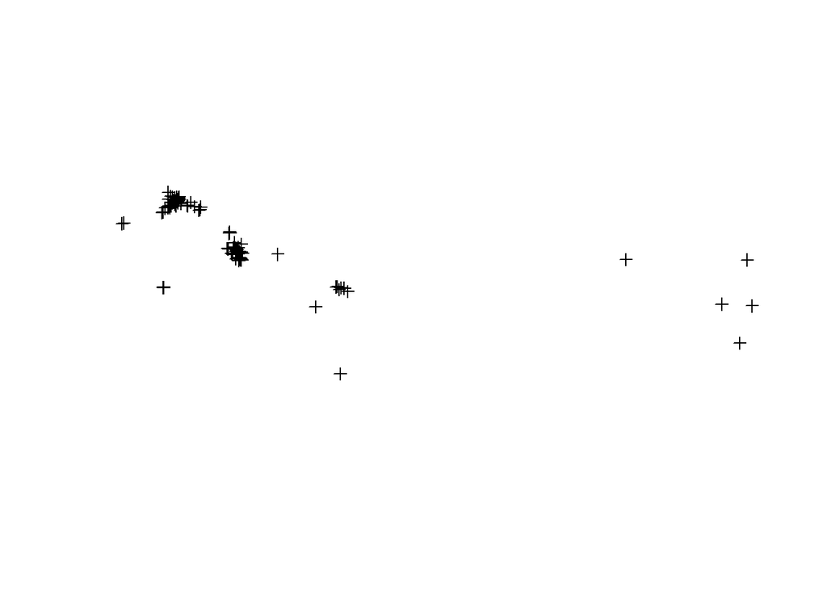

```r
#It is the same object, but it has been replaced with a SpatialPointsDataFrame
plot(Data)
```

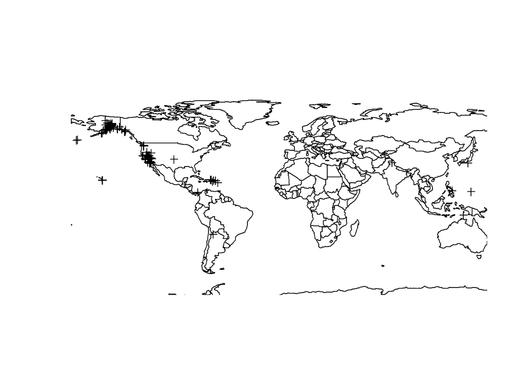

```r
#It is the same object, but it has been replaced with a SpatialPointsDataFrame
plot(Data)
#We can re-import the shapefile we downloaded  to provide
#a context to this map.
NatEarth <- shapefile("Shapefile/ne_110m_admin_0_countries.shp")
plot(NatEarth, add=T)
```

#### 1.1.2.4 Understanding Projections

- Why do we need a projection
- How to set the projection in our data
- Most common types of projections

```r
#Load the required packages
library(sp)
library(raster)
```

```r
#Set the URL with the CSV Files
URL <- "http://earthquake.usgs.gov/earthquakes/feed/v1.0/summary/all_day.csv"

#Loading CSV Files
Data <- read.table(file=URL,
                   sep=",",
                   header=TRUE,
                   na.string="")

Data$latitude[1]
```

```
## [1] 38.82567
```

```r
Data$longitude[1]
```

```
## [1] -122.812
```

```r
#Transformation into a spatial object
coordinates(Data)=~longitude+latitude

#Assign projection
projection(Data)=CRS("+init=epsg:4326")


#This is a list of common projections
#from: http://spatialreference.org/
#CRS("+init=epsg:3857") -> wgs84/OSM
#CRS("+init=epsg:4326") -> Unprojected WGS84 for Google Maps
#CRS("+init=epsg:3395") -> wgs84/World Mercator

#Alternatively projections can be assigned using data from
#another spatial object.
NatEarth <- shapefile("Shapefile/ne_110m_admin_0_countries.shp")

projection(Data)=projection(NatEarth)
```

#### 1.1.2.5 Basic time/date formats (Temporal Component)

- Dealing with the time components
- The standard date format
- The powerful POSIXct

```r
#We can identify the column with time data with names()
names(Data)
```

```
##  [1] "time"            "depth"           "mag"
##  [4] "magType"         "nst"             "gap"
##  [7] "dmin"            "rms"             "net"
## [10] "id"              "updated"         "place"
## [13] "type"            "horizontalError" "depthError"
## [16] "magError"        "magNst"          "status"
## [19] "locationSource"  "magSource"
```

```r
#Is this column in the right format?
class(Data$time)
```

```
## [1] "factor"
```

```r
#Let's examine one entry of this vector
Data$time[1]
```

```
## [1] 2017-12-10T01:14:39.820Z
## 236 Levels: 2017-12-09T01:38:56.510Z ... 2017-12-10T01:14:39.820Z
```

```r
Date.Class <- as.Date(Data$time[1], format = "%Y-%m-%dT%H:%M:%S")
#The abbreviations used for the option format can be found here:
#http://www.inside-r.org/r-doc/base/strptime

class(Date.Class)
```

```
## [1] "Date"
```

```r
#The powerful POSIYct format
Date.Pos <- as.POSIXct(Data$time[1], format = "%Y-%m-%dT%H:%M:%S")

class(Date.Pos)
```

```
## [1] "POSIXct" "POSIXt"
```

```r
#This tranformation can be done for the whole data.frame at once.
#Thus, we can create a new column in our data.frame with
#date/time information in POSIXct
Data$DateTime <- as.POSIXct(Data$time, format = "%Y-%m-%dT%H:%M:%S")

class(Data$DateTime)
```

```
## [1] "POSIXct" "POSIXt"
```

```r
#This allows us to subset the dataset by date or time
#Extract data before or equal to the 8th of June at 12:30
subset(Data, DateTime <= as.POSIXct('2016-06-08 12:30'))
```

```
## class       : SpatialPointsDataFrame
## features    : 0
## coord. ref. : +proj=longlat +datum=WGS84 +no_defs +ellps=WGS84 +towgs84=0,0,0
## variables   : 21
## names       : time, depth,  mag, magType,  nst,  gap, dmin,  rms,  net,   id, updated, place, type, horizontalError, depthError, ...
```

```r
#Extract data after the 8th of June at 12:30
subset(Data, DateTime > as.POSIXct('2016-06-08 12:30'))
```

```
## class       : SpatialPointsDataFrame
## features    : 236
## extent      : -176.1317, 140.2081, -24.068, 67.1857  (xmin, xmax, ymin, ymax)
## coord. ref. : +proj=longlat +datum=WGS84 +no_defs +ellps=WGS84 +towgs84=0,0,0
## variables   : 21
## names       :                     time,  depth,   mag, magType, nst,    gap,      dmin,    rms, net,         id,                  updated,                         place,       type, horizontalError, depthError, ...
## min values  : 2017-12-09T01:38:56.510Z,  -0.03, -0.10,      mb,   3,  21.00, 0.0006543, 0.0100,  ak, ak17545480, 2017-12-09T01:46:58.146Z, 109km WSW of Gustavus, Alaska, earthquake,            0.10,       0.00, ...
## max values  : 2017-12-10T01:14:39.820Z, 329.35,  6.10,     mww, 113, 351.00, 5.7360000, 1.4200,  uw, uw61334657, 2017-12-10T01:25:02.883Z,                   Arafura Sea, earthquake,           17.36,      33.90, ...
```

```r
#Extract data collected only at 11, 12 and 13, any day or month
subset(Data, format(DateTime,'%H') %in% c("11","12","13"))
```

```
## class       : SpatialPointsDataFrame
## features    : 25
## extent      : -176.1317, -66.2328, 19.2178, 64.5364  (xmin, xmax, ymin, ymax)
## coord. ref. : +proj=longlat +datum=WGS84 +no_defs +ellps=WGS84 +towgs84=0,0,0
## variables   : 21
## names       :                     time,  depth,   mag, magType, nst,    gap,     dmin,    rms, net,           id,                  updated,                     place,       type, horizontalError, depthError, ...
## min values  : 2017-12-09T11:00:47.501Z,   1.07, -0.20,      md,   4,  48.00, 0.001715, 0.0100,  ak,   ak17552423, 2017-12-09T11:18:42.243Z,    10km NE of Aguanga, CA, earthquake,            0.20,       0.10, ...
## max values  : 2017-12-09T13:54:24.752Z, 127.00,  3.80,      ml,  34, 351.00, 1.015100, 1.1200,  pr, pr2017343002, 2017-12-09T21:51:14.022Z, 9km NW of The Geysers, CA, earthquake,           17.36,       8.69, ...
```

```r
#Extract data collected only on day 8th, any month or year
subset(Data, format(DateTime,'%d') == "08")
```

```
## class       : SpatialPointsDataFrame
## features    : 0
## coord. ref. : +proj=longlat +datum=WGS84 +no_defs +ellps=WGS84 +towgs84=0,0,0
## variables   : 21
## names       : time, depth,  mag, magType,  nst,  gap, dmin,  rms,  net,   id, updated, place, type, horizontalError, depthError, ...
```

```r
#More examples available at:
#https://stat.ethz.ch/pipermail/r-help/2011-September/289364.html
```

### 1.1.3 Section 3: Importing Raster Data

- **Introducing the Raster Format**
- **Reading Raster Data**
- **Mosaicking**
- **Stacking to include the Temporal Component**

#### 1.1.3.1 Introducing the Raster Format

- Introducing the raster format
- Reading raster data in NetCDF
- Mosaicking
- Stacking to include the temporal component

```r
#Load the required packages
library(rgdal)
library(raster)
library(RCurl)
```

```r
#Define the URL of the FTP site
FTP <- "ftp://ftp.star.nesdis.noaa.gov/pub/corp/scsb/wguo/data/VHP_4km/geo_TIFF/"

#Create a list with all the files on the FTP site
list <- getURL(FTP, dirlistonly = FALSE)

#The list of files from the FTP site is this time a bit more complex to handle.
#We first need to divide by \r\n like the last time
List.Temp <- strsplit(list, split="\r\n")

#This time though this does not create a list of files,
#but more characters are included.
#Luckily, the file names are always in the same position of the string.
FileList <- lapply(List.Temp, substr, start=56, stop=92)

#Now we have the list of all the files on the FTP site, from 1981.
#We are only interested in files from 2016, so we can use the function grep
#to identify only the string with a certain word in them.
grep("P2016", unlist(FileList))

#Now we can subset the list and obtain only the names of the files from 2016.
Data2016 <- unlist(FileList)[grep("P2016", unlist(FileList))]
Data2016VCI <- unlist(Data2016)[grep("VCI", unlist(Data2016))]
```

```r
#Create a new directory where to download these files
DIR <- paste(getwd(),"/NDVIRaster",sep="")
dir.create(DIR)
```

```r
#Loop to download the files
for(FileName in unlist(Data2016VCI)){
  URL <- paste0(FTP, FileName)
  download.file(URL, destfile=paste0(DIR,"/",FileName), method="auto", mode="wb")

}
```

```r
#Create a list with all the files in the directory
ListFiles <- list.files(path="NDVIRaster", pattern=".tif", full.names=TRUE)


#Open a raster file with rgdal
ndvi.rgdal <- readGDAL(ListFiles[1])
```

```
## NDVIRaster/VHP.G04.C07.NP.P2016001.VH.VCI.tif has GDAL driver GTiff
## and has 3616 rows and 10000 columns
```

```r
class(ndvi.rgdal)
```

```
## [1] "SpatialGridDataFrame"
## attr(,"package")
## [1] "sp"
```

```r
object.size(ndvi.rgdal)
```

```
## 289284296 bytes
```

```r
#Open a raster file with raster
ndvi.raster <- raster(ListFiles[1])

class(ndvi.raster)
```

```
## [1] "RasterLayer"
## attr(,"package")
## [1] "raster"
```

```r
object.size(ndvi.raster)
```

```
## 12048 bytes
```

#### 1.1.3.2 Reading Raster Data

- Download data from European centre for medium-range whether forecasts(ECMWF)
- Opening NETCDF data
- creating daily or hourly averages

```r
#Load the required packages
library(raster)

#For this video we also need to install and load the library netcdf4
#install.packages("ncdf4")
library(ncdf4)

ListFiles <- list.files(path="NETCDF", pattern=".nc", full.names=TRUE)

#Open a raster file in NetCDF
temp_ncdf <- nc_open(ListFiles[1])
#Visualize the name of the variable
names(temp_ncdf$var)
```

```
## [1] "t2m"
```

```r
#NetCDF are 4D data, meaning they have an x and y dimensions
#plus a z dimension, which is the variable;
#and also a time dimension.
#This means that the file has multiple layers, one for each time window.
#We can open it as a multi-layer raster with the function brick
Temperature <- brick(ListFiles[1], varname="t2m", layer="time")
str(Temperature)
```

```
## Formal class 'RasterBrick' [package "raster"] with 12 slots
##   ..@ file    :Formal class '.RasterFile' [package "raster"] with 13 slots
##   .. .. ..@ name        : chr "E:\\Projects\\sumendar\\content\\post\\NETCDF\\_grib2netcdf-atls03-98f536083ae965b31b0d04811be6f4c6-CXx_7x.nc"
##   .. .. ..@ datanotation: chr "FLT4S"
##   .. .. ..@ byteorder   : chr "little"
##   .. .. ..@ nodatavalue : num -32767
##   .. .. ..@ NAchanged   : logi FALSE
##   .. .. ..@ nbands      : int 124
##   .. .. ..@ bandorder   : chr "BIL"
##   .. .. ..@ offset      : int 0
##   .. .. ..@ toptobottom : logi FALSE
##   .. .. ..@ blockrows   : int 0
##   .. .. ..@ blockcols   : int 0
##   .. .. ..@ driver      : chr "netcdf"
##   .. .. ..@ open        : logi FALSE
##   ..@ data    :Formal class '.MultipleRasterData' [package "raster"] with 14 slots
##   .. .. ..@ values    : logi[0 , 0 ]
##   .. .. ..@ offset    : num 0
##   .. .. ..@ gain      : num 1
##   .. .. ..@ inmemory  : logi FALSE
##   .. .. ..@ fromdisk  : logi TRUE
##   .. .. ..@ nlayers   : int 124
##   .. .. ..@ dropped   : NULL
##   .. .. ..@ isfactor  : logi FALSE
##   .. .. ..@ attributes: list()
##   .. .. ..@ haveminmax: logi FALSE
##   .. .. ..@ min       : num [1:124] Inf Inf Inf Inf Inf ...
##   .. .. ..@ max       : num [1:124] -Inf -Inf -Inf -Inf -Inf ...
##   .. .. ..@ unit      : chr "K"
##   .. .. ..@ names     : chr [1:124] "X2016.02.29.23.36.40" "X2016.03.01.05.36.40" "X2016.03.01.11.36.40" "X2016.03.01.17.36.40" ...
##   ..@ legend  :Formal class '.RasterLegend' [package "raster"] with 5 slots
##   .. .. ..@ type      : chr(0)
##   .. .. ..@ values    : logi(0)
##   .. .. ..@ color     : logi(0)
##   .. .. ..@ names     : logi(0)
##   .. .. ..@ colortable: logi(0)
##   ..@ title   : chr "2 metre temperature"
##   ..@ extent  :Formal class 'Extent' [package "raster"] with 4 slots
##   .. .. ..@ xmin: num -180
##   .. .. ..@ xmax: num 180
##   .. .. ..@ ymin: num -90.4
##   .. .. ..@ ymax: num 90.4
##   ..@ rotated : logi FALSE
##   ..@ rotation:Formal class '.Rotation' [package "raster"] with 2 slots
##   .. .. ..@ geotrans: num(0)
##   .. .. ..@ transfun:function ()
##   ..@ ncols   : int 480
##   ..@ nrows   : int 241
##   ..@ crs     :Formal class 'CRS' [package "sp"] with 1 slot
##   .. .. ..@ projargs: chr "+proj=longlat +datum=WGS84 +ellps=WGS84 +towgs84=0,0,0"
##   ..@ history : list()
##   ..@ z       :List of 1
##   .. ..$ Date/time: chr [1:124] "2016-02-29 23:36:40" "2016-03-01 05:36:40" "2016-03-01 11:36:40" "2016-03-01 17:36:40" ...
```

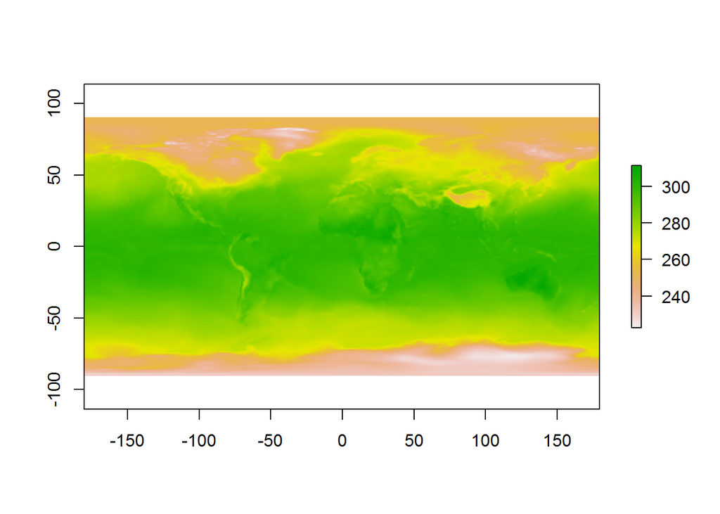

```r
#Create a time index for the multi-layer object
TIME <- as.POSIXct(substr(Temperature@data@names,
                          start=2, stop=20),
                   format="%Y.%m.%d.%H.%M.%S")
df <- data.frame(INDEX = 1:length(TIME), TIME=TIME)        #Now we can create a subset of only the first day of the month
subset <- df[format(df$TIME, "%d") == "01",]

sub.temp <- Temperature[[subset$INDEX]]

temp_day1 <- calc(sub.temp, fun=mean)
plot(temp_day1)
```

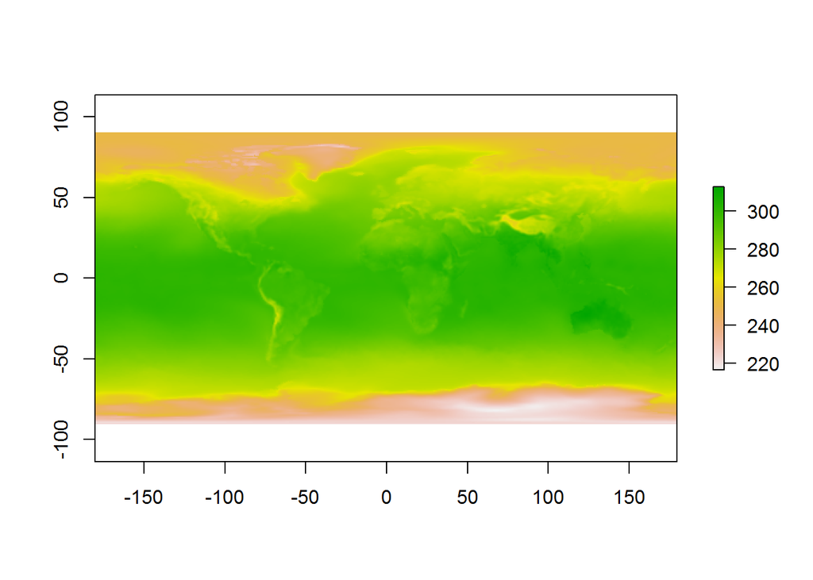

```r
#Alternatively, we can extract only data collected at 6am.
subset <- df[format(df$TIME, "%H") == "05",]

sub.temp <- Temperature[[subset$INDEX]]

temp_hour6 <- calc(sub.temp, fun=mean)
plot(temp_hour6)
```

#### 1.1.3.3 Mosaicking

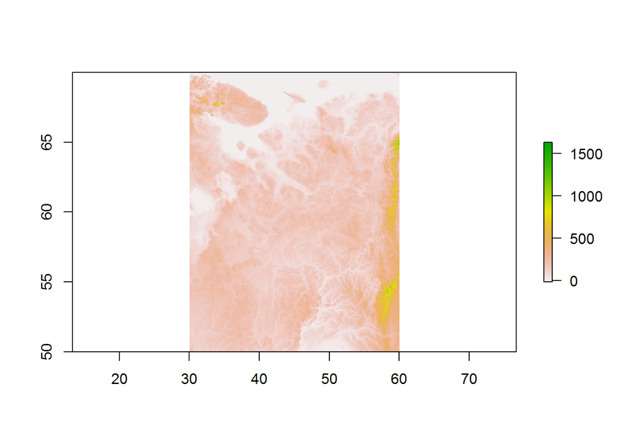

```r
#Load the required packages
library(raster)
setwd("E:/Projects/sumendar/content/post/DTM_Data")
ListFiles <- list.files(path=".", pattern=".tif", full.names=FALSE)
#Turn the list of files into a list of raster objects with lapply
ListRasters <- lapply(ListFiles, raster)

#Merge all the raster objects into one.
#NOTE: This step may be time-consuming!!
DTM <- do.call("merge", ListRasters)

#Plot the DTM to take a look at the result
plot(DTM)
```

#### 1.1.3.4 Stacking to include the Temporal Component

### 1.1.4 Section 4: Exporting Data

**Exporting Data in Tables** **Exporting Vector Data(ESRI shp file)** **Exporting Rasters in Various Formats(GeoTIFF, ASCII Grids)** **Exporting Data for WebGIS Systems(GeoJSON, KML)**

#### 1.1.4.1 Exporting Data in Tables

#### 1.1.4.2 Exporting Vector Data(ESRI shp file)

#### 1.1.4.3 Exporting Rasters in Various Formats(GeoTIFF, ASCII Grids)

#### 1.1.4.4 Exporting Data for WebGIS Systems(GeoJSON, KML)

## 1.2 Section 5 to 9: Exploring Descriptive statistics, Data Manipulations & Data Visualisation

Deep understanding the basics of data analysis

- plotting & manipulating spatio temporal data
- Creation of static & interactive spatio temportal maps

### 1.2.1 Section 5: Descriptive Statistics

- **Preparing the Dataset**
- **Measuring Spread (Standard Deviation and Standard Distance)**
- **Understanding Your Data with Plots**
- **Plotting for Multivariate Data**
- **Finding Outliers**

#### 1.2.1.1 Preparing the Dataset

#### 1.2.1.2 Measuring Spread (Standard Deviation and Standard Distance)

#### 1.2.1.3 Understanding Your Data with Plots

#### 1.2.1.4 Plotting for Multivariate Data

#### 1.2.1.5 Finding Outliers

### 1.2.2 Section 6: Manipulating Vector Data

- **Introduction**
- **Re-Projecting Your Data**
- **Intersection**
- **Buffer and Distance**
- **Union and Overlay**

#### 1.2.2.1 Introduction

#### 1.2.2.2 Re-Projecting Your Data

#### 1.2.2.3 Intersection

#### 1.2.2.4 Buffer and Distance

#### 1.2.2.5 Union and Overlay

### 1.2.3 Section 7: Manipulating Raster Data

- **Introduction**
- **Converting Vector/Table Data into Raster**
- **Subsetting and Selection**
- **Filtering**
- **Raster Calculator**

#### 1.2.3.1 Introduction

#### 1.2.3.2 Converting Vector/Table Data into Raster

#### 1.2.3.3 Subsetting and Selection

#### 1.2.3.4 Filtering

#### 1.2.3.5 Raster Calculator

### 1.2.4 Section 8: Visualizing Spatial Data

- **Plotting Basics**
- **Adding Layers**
- **Color Scale**
- **Creating Multivariate Plots**
- **Handling the Temporal Component**

#### 1.2.4.1 Plotting Basics

#### 1.2.4.2 Adding Layers

#### 1.2.4.3 Color Scale

#### 1.2.4.4 Creating Multivariate Plots

#### 1.2.4.5 Handling the Temporal Component

### 1.2.5 Section 9: Interactive Maps

- **Introduction**
- **Plotting Vector Data on Google Maps**
- **Adding Layers**
- **Plotting Raster Data on Google Maps**
- **Using Leaflet to Plot on Open Street Maps**

#### 1.2.5.1 Introduction

#### 1.2.5.2 Plotting Vector Data on Google Maps

#### 1.2.5.3 Adding Layers

#### 1.2.5.4 Plotting Raster Data on Google Maps

#### 1.2.5.5 Using Leaflet to Plot on Open Street Maps

## 1.3 Section 10 to 15: Working with Real life data, experiment & perform advanced data analysis

- point pattern analysis(Using crime data in UK)
- time series analysis (Wind speed data)
- geo statistical interpolation (Air polution)
- statistical & machine learning regression
  - Random forest algorithm
- cluster analysis Using Earthquake data
  - k-means algorithm -heirarchial clustering

### 1.3.1 Section 10: Creating Global Economic Maps with Open Data

- **Introduction**
- **Importing Data from the World Bank**
- **Adding Geocoding Information**
- **Concluding Remarks**

#### 1.3.1.1 Introduction

#### 1.3.1.2 Importing Data from the World Bank

#### 1.3.1.3 Adding Geocoding Information

#### 1.3.1.4 Concluding Remarks

### 1.3.2 Section 11: Point Pattern Analysis of Crime in the UK

- **Theoretical Background**
- **Introduction**
- **Intensity and Density**
- **Spatial Distribution**
- **Modelling**

#### 1.3.2.1 Theoretical Background

#### 1.3.2.2 Introduction

#### 1.3.2.3 Intensity and Density

#### 1.3.2.4 Spatial Distribution

#### 1.3.2.5 Modelling

### 1.3.3 Section 12: Cluster Analysis of Earthquake Data

- **Theoretical Background**
- **Data Preparation**
- **K-Means Clustering**
- **Optimal Number of Clusters**
- **Hierarchical Clustering**
- **Concluding**

#### 1.3.3.1 Theoretical Background

#### 1.3.3.2 Data Preparation

#### 1.3.3.3 K-Means Clustering

#### 1.3.3.4 Optimal Number of Clusters

#### 1.3.3.5 Hierarchical Clustering

#### 1.3.3.6 Concluding

### 1.3.4 Section 13: Time Series Analysis of Wind Speed Data

- **Theoretical Background**
- **Reading Time-Series in R**
- **Subsetting and Temporal Functions**
- **Decomposition and Correlation**
- **Forecasting**

#### 1.3.4.1 Theoretical Background

#### 1.3.4.2 Reading Time-Series in R

#### 1.3.4.3 Subsetting and Temporal Functions

#### 1.3.4.4 Decomposition and Correlation

#### 1.3.4.5 Forecasting

### 1.3.5 Section 14: Geostatistics

- **Theoretical Background**
- **Data Preparation**
- **Mapping with Deterministic Estimators**
- **Analyzing Trend and Checking Normality**
- **Variogram Analysis**
- **Mapping with kriging**

#### 1.3.5.1 Theoretical Background

#### 1.3.5.2 Data Preparation

#### 1.3.5.3 Mapping with Deterministic Estimators

#### 1.3.5.4 Analyzing Trend and Checking Normality

#### 1.3.5.5 Variogram Analysis

#### 1.3.5.6 Mapping with kriging

### 1.3.6 Section 15: Regression and Statistical Learning

- **Theoretical Background**
- **Dataset**
- **Linear Regression**
- **Regression Trees**
- **Support Vector Machines**

#### 1.3.6.1 Theoretical Background

#### 1.3.6.2 Dataset

#### 1.3.6.3 Linear Regression

#### 1.3.6.4 Regression Trees

#### 1.3.6.5 Support Vector Machines